# Data Manipulation : dplyr

Gustavo Bertrán

2025-09-18 17:13:50

# Data Wrangling with `dplyr`

## Rows

- `filter()`: keep rows matching conditions
- `arrange()` : reorder rows
- `slice()` : select rows by position ## Columns
- `select()`: pick column by name or positions
- `rename()`: rename columns
- `mutate` : create new columns ## Groups
- `group_by()` : define groups
- `summarize()`: collapse data within groups

## `%>%`: “then” function

# `dplyr`: the pipe `%>%`

- All dplyr funcitons take a data frame as the first argument.
- Without the pipe, you’d need nested calls or temporary objects.
- The pipe can be read as “then”
- It passes the result of one function into the nedxt.
- This makes your code:
  - Easier to read
  - Easier to write
  - Easier to debug # Example dataset

```r
library(dplyr)
data("starwars")
head(starwars)
```

```
## # A tibble: 6 × 14
##   name      height  mass hair_color skin_color eye_color birth_year sex   gender
##   <chr>      <int> <dbl> <chr>      <chr>      <chr>          <dbl> <chr> <chr>
## 1 Luke Sky…    172    77 blond      fair       blue            19   male  mascu…
## 2 C-3PO        167    75 <NA>       gold       yellow         112   none  mascu…
## 3 R2-D2         96    32 <NA>       white, bl… red             33   none  mascu…
## 4 Darth Va…    202   136 none       white      yellow          41.9 male  mascu…
## 5 Leia Org…    150    49 brown      light      brown           19   fema… femin…
## 6 Owen Lars    178   120 brown, gr… light      blue            52   male  mascu…
## # ℹ 5 more variables: homeworld <chr>, species <chr>, films <list>,
## #   vehicles <list>, starships <list>
```

# `dplyr`:`filter()`

- `filter()` selects a subset of rows in a data frame or tibble
- **The first argument is always the data frame**
- ** The second argument (and subsequent) are conditions on variables, keeping only rows where the condition is TRUE

```r
starwars %>%
  filter(species == "Droid")
```

```
## # A tibble: 6 × 14
##   name   height  mass hair_color skin_color  eye_color birth_year sex   gender
##   <chr>   <int> <dbl> <chr>      <chr>       <chr>          <dbl> <chr> <chr>
## 1 C-3PO     167    75 <NA>       gold        yellow           112 none  masculi…
## 2 R2-D2      96    32 <NA>       white, blue red               33 none  masculi…
## 3 R5-D4      97    32 <NA>       white, red  red               NA none  masculi…
## 4 IG-88     200   140 none       metal       red               15 none  masculi…
## 5 R4-P17     96    NA none       silver, red red, blue         NA none  feminine
## 6 BB8        NA    NA none       none        black             NA none  masculi…
## # ℹ 5 more variables: homeworld <chr>, species <chr>, films <list>,
## #   vehicles <list>, starships <list>
```

```r
# in base r it would look like:
subset(starwars, species == "Droid")
```

```
## # A tibble: 6 × 14
##   name   height  mass hair_color skin_color  eye_color birth_year sex   gender
##   <chr>   <int> <dbl> <chr>      <chr>       <chr>          <dbl> <chr> <chr>
## 1 C-3PO     167    75 <NA>       gold        yellow           112 none  masculi…
## 2 R2-D2      96    32 <NA>       white, blue red               33 none  masculi…
## 3 R5-D4      97    32 <NA>       white, red  red               NA none  masculi…
## 4 IG-88     200   140 none       metal       red               15 none  masculi…
## 5 R4-P17     96    NA none       silver, red red, blue         NA none  feminine
## 6 BB8        NA    NA none       none        black             NA none  masculi…
## # ℹ 5 more variables: homeworld <chr>, species <chr>, films <list>,
## #   vehicles <list>, starships <list>
```

```r
#another example
starwars %>%
  filter(skin_color=="light",
         eye_color=="brown" &
           hair_color=="black")
```

```
## # A tibble: 1 × 14
##   name      height  mass hair_color skin_color eye_color birth_year sex   gender
##   <chr>      <int> <dbl> <chr>      <chr>      <chr>          <dbl> <chr> <chr>
## 1 Biggs Da…    183    84 black      light      brown             24 male  mascu…
## # ℹ 5 more variables: homeworld <chr>, species <chr>, films <list>,
## #   vehicles <list>, starships <list>
```

# `dplyr` : `arrange()`

- `arrange()` reorders the rows of a data frame or tibble
- The first argument is the data frame, followed by one or more column names (or expressions) to order by
- If multiple columns are provided, later columns are used to break ties in earlier ones

```r
starwars %>%
  arrange(height, mass)
```

```
## # A tibble: 87 × 14
##    name     height  mass hair_color skin_color eye_color birth_year sex   gender
##    <chr>     <int> <dbl> <chr>      <chr>      <chr>          <dbl> <chr> <chr>
##  1 Yoda         66    17 white      green      brown            896 male  mascu…
##  2 Ratts T…     79    15 none       grey, blue unknown           NA male  mascu…
##  3 Wicket …     88    20 brown      brown      brown              8 male  mascu…
##  4 Dud Bolt     94    45 none       blue, grey yellow            NA male  mascu…
##  5 R2-D2        96    32 <NA>       white, bl… red               33 none  mascu…
##  6 R4-P17       96    NA none       silver, r… red, blue         NA none  femin…
##  7 R5-D4        97    32 <NA>       white, red red               NA none  mascu…
##  8 Sebulba     112    40 none       grey, red  orange            NA male  mascu…
##  9 Gasgano     122    NA none       white, bl… black             NA male  mascu…
## 10 Watto       137    NA black      blue, grey yellow            NA male  mascu…
## # ℹ 77 more rows
## # ℹ 5 more variables: homeworld <chr>, species <chr>, films <list>,
## #   vehicles <list>, starships <list>
```

```r
starwars %>%
  arrange(desc(height))
```

```
## # A tibble: 87 × 14
##    name     height  mass hair_color skin_color eye_color birth_year sex   gender
##    <chr>     <int> <dbl> <chr>      <chr>      <chr>          <dbl> <chr> <chr>
##  1 Yarael …    264    NA none       white      yellow          NA   male  mascu…
##  2 Tarfful     234   136 brown      brown      blue            NA   male  mascu…
##  3 Lama Su     229    88 none       grey       black           NA   male  mascu…
##  4 Chewbac…    228   112 brown      unknown    blue           200   male  mascu…
##  5 Roos Ta…    224    82 none       grey       orange          NA   male  mascu…
##  6 Grievous    216   159 none       brown, wh… green, y…       NA   male  mascu…
##  7 Taun We     213    NA none       grey       black           NA   fema… femin…
##  8 Rugor N…    206    NA none       green      orange          NA   male  mascu…
##  9 Tion Me…    206    80 none       grey       black           NA   male  mascu…
## 10 Darth V…    202   136 none       white      yellow          41.9 male  mascu…
## # ℹ 77 more rows
## # ℹ 5 more variables: homeworld <chr>, species <chr>, films <list>,
## #   vehicles <list>, starships <list>
```

# `dplyr`: `slice()`

- selects rows by their position
- Comes with several helper functions for common use cases:
  - `slice_head()`: select the first n rows
  - `slice_tail()`: select the last n rows

```r
starwars %>%
  slice(5:10)
```

```
## # A tibble: 6 × 14
##   name      height  mass hair_color skin_color eye_color birth_year sex   gender
##   <chr>      <int> <dbl> <chr>      <chr>      <chr>          <dbl> <chr> <chr>
## 1 Leia Org…    150    49 brown      light      brown             19 fema… femin…
## 2 Owen Lars    178   120 brown, gr… light      blue              52 male  mascu…
## 3 Beru Whi…    165    75 brown      light      blue              47 fema… femin…
## 4 R5-D4         97    32 <NA>       white, red red               NA none  mascu…
## 5 Biggs Da…    183    84 black      light      brown             24 male  mascu…
## 6 Obi-Wan …    182    77 auburn, w… fair       blue-gray         57 male  mascu…
## # ℹ 5 more variables: homeworld <chr>, species <chr>, films <list>,
## #   vehicles <list>, starships <list>
```

```r
starwars %>%
  slice_head(n=8)
```

```
## # A tibble: 8 × 14
##   name      height  mass hair_color skin_color eye_color birth_year sex   gender
##   <chr>      <int> <dbl> <chr>      <chr>      <chr>          <dbl> <chr> <chr>
## 1 Luke Sky…    172    77 blond      fair       blue            19   male  mascu…
## 2 C-3PO        167    75 <NA>       gold       yellow         112   none  mascu…
## 3 R2-D2         96    32 <NA>       white, bl… red             33   none  mascu…
## 4 Darth Va…    202   136 none       white      yellow          41.9 male  mascu…
## 5 Leia Org…    150    49 brown      light      brown           19   fema… femin…
## 6 Owen Lars    178   120 brown, gr… light      blue            52   male  mascu…
## 7 Beru Whi…    165    75 brown      light      blue            47   fema… femin…
## 8 R5-D4         97    32 <NA>       white, red red             NA   none  mascu…
## # ℹ 5 more variables: homeworld <chr>, species <chr>, films <list>,
## #   vehicles <list>, starships <list>
```

```r
starwars %>%
  slice_tail(n=5)
```

```
## # A tibble: 5 × 14
##   name      height  mass hair_color skin_color eye_color birth_year sex   gender
##   <chr>      <int> <dbl> <chr>      <chr>      <chr>          <dbl> <chr> <chr>
## 1 Finn          NA    NA black      dark       dark              NA male  mascu…
## 2 Rey           NA    NA brown      light      hazel             NA fema… femin…
## 3 Poe Dame…     NA    NA brown      light      brown             NA male  mascu…
## 4 BB8           NA    NA none       none       black             NA none  mascu…
## 5 Captain …     NA    NA none       none       unknown           NA fema… femin…
## # ℹ 5 more variables: homeworld <chr>, species <chr>, films <list>,
## #   vehicles <list>, starships <list>
```

# `dplyr`: `select()`

- Makes it easy to extract specific columns by name( or whith helper functions)

```r
starwars %>%
  select(name, hair_color, skin_color, eye_color) %>%
  slice_head(n=10)
```

```
## # A tibble: 10 × 4
##    name               hair_color    skin_color  eye_color
##    <chr>              <chr>         <chr>       <chr>
##  1 Luke Skywalker     blond         fair        blue
##  2 C-3PO              <NA>          gold        yellow
##  3 R2-D2              <NA>          white, blue red
##  4 Darth Vader        none          white       yellow
##  5 Leia Organa        brown         light       brown
##  6 Owen Lars          brown, grey   light       blue
##  7 Beru Whitesun Lars brown         light       blue
##  8 R5-D4              <NA>          white, red  red
##  9 Biggs Darklighter  black         light       brown
## 10 Obi-Wan Kenobi     auburn, white fair        blue-gray
```

```r
starwars %>%
  select(!hair_color,! eye_color)
```

```
## # A tibble: 87 × 14
##    name      height  mass skin_color eye_color birth_year sex   gender homeworld
##    <chr>      <int> <dbl> <chr>      <chr>          <dbl> <chr> <chr>  <chr>
##  1 Luke Sky…    172    77 fair       blue            19   male  mascu… Tatooine
##  2 C-3PO        167    75 gold       yellow         112   none  mascu… Tatooine
##  3 R2-D2         96    32 white, bl… red             33   none  mascu… Naboo
##  4 Darth Va…    202   136 white      yellow          41.9 male  mascu… Tatooine
##  5 Leia Org…    150    49 light      brown           19   fema… femin… Alderaan
##  6 Owen Lars    178   120 light      blue            52   male  mascu… Tatooine
##  7 Beru Whi…    165    75 light      blue            47   fema… femin… Tatooine
##  8 R5-D4         97    32 white, red red             NA   none  mascu… Tatooine
##  9 Biggs Da…    183    84 light      brown           24   male  mascu… Tatooine
## 10 Obi-Wan …    182    77 fair       blue-gray       57   male  mascu… Stewjon
## # ℹ 77 more rows
## # ℹ 5 more variables: species <chr>, films <list>, vehicles <list>,
## #   starships <list>, hair_color <chr>
```

- We can use `-`to extract all except particular columns

```r
starwars %>%
  select(-name, -skin_color)
```

```
## # A tibble: 87 × 12
##    height  mass hair_color   eye_color birth_year sex   gender homeworld species
##     <int> <dbl> <chr>        <chr>          <dbl> <chr> <chr>  <chr>     <chr>
##  1    172    77 blond        blue            19   male  mascu… Tatooine  Human
##  2    167    75 <NA>         yellow         112   none  mascu… Tatooine  Droid
##  3     96    32 <NA>         red             33   none  mascu… Naboo     Droid
##  4    202   136 none         yellow          41.9 male  mascu… Tatooine  Human
##  5    150    49 brown        brown           19   fema… femin… Alderaan  Human
##  6    178   120 brown, grey  blue            52   male  mascu… Tatooine  Human
##  7    165    75 brown        blue            47   fema… femin… Tatooine  Human
##  8     97    32 <NA>         red             NA   none  mascu… Tatooine  Droid
##  9    183    84 black        brown           24   male  mascu… Tatooine  Human
## 10    182    77 auburn, whi… blue-gray       57   male  mascu… Stewjon   Human
## # ℹ 77 more rows
## # ℹ 3 more variables: films <list>, vehicles <list>, starships <list>
```

- We can also specify column positions, or combine column positions and names

```r
starwars %>%
  select(1,2, species) %>%
  filter(species=="Droid") %>%
  summarise(species)
```

```
## # A tibble: 6 × 1
##   species
##   <chr>
## 1 Droid
## 2 Droid
## 3 Droid
## 4 Droid
## 5 Droid
## 6 Droid
```

```r
starwars %>%
  select(contains('c'))
```

```
## # A tibble: 87 × 5
##    hair_color    skin_color  eye_color species vehicles
##    <chr>         <chr>       <chr>     <chr>   <list>
##  1 blond         fair        blue      Human   <chr [2]>
##  2 <NA>          gold        yellow    Droid   <chr [0]>
##  3 <NA>          white, blue red       Droid   <chr [0]>
##  4 none          white       yellow    Human   <chr [0]>
##  5 brown         light       brown     Human   <chr [1]>
##  6 brown, grey   light       blue      Human   <chr [0]>
##  7 brown         light       blue      Human   <chr [0]>
##  8 <NA>          white, red  red       Droid   <chr [0]>
##  9 black         light       brown     Human   <chr [0]>
## 10 auburn, white fair        blue-gray Human   <chr [1]>
## # ℹ 77 more rows
```

#`dplyr`: `select()` with `starts_with()` - `starts_with()` and `ends_with()` offer more pecificity for `select()`

```r
starwars %>%
  select(starts_with('n'))
```

```
## # A tibble: 87 × 1
##    name
##    <chr>
##  1 Luke Skywalker
##  2 C-3PO
##  3 R2-D2
##  4 Darth Vader
##  5 Leia Organa
##  6 Owen Lars
##  7 Beru Whitesun Lars
##  8 R5-D4
##  9 Biggs Darklighter
## 10 Obi-Wan Kenobi
## # ℹ 77 more rows
```

# `dplyr`:`rename()`

- changes column names wihtout altering the data

```r
#First the name you want, second the current name
starwars %>%
  rename(Character = name)
```

```
## # A tibble: 87 × 14
##    Character       height  mass hair_color skin_color eye_color birth_year sex
##    <chr>            <int> <dbl> <chr>      <chr>      <chr>          <dbl> <chr>
##  1 Luke Skywalker     172    77 blond      fair       blue            19   male
##  2 C-3PO              167    75 <NA>       gold       yellow         112   none
##  3 R2-D2               96    32 <NA>       white, bl… red             33   none
##  4 Darth Vader        202   136 none       white      yellow          41.9 male
##  5 Leia Organa        150    49 brown      light      brown           19   fema…
##  6 Owen Lars          178   120 brown, gr… light      blue            52   male
##  7 Beru Whitesun …    165    75 brown      light      blue            47   fema…
##  8 R5-D4               97    32 <NA>       white, red red             NA   none
##  9 Biggs Darkligh…    183    84 black      light      brown           24   male
## 10 Obi-Wan Kenobi     182    77 auburn, w… fair       blue-gray       57   male
## # ℹ 77 more rows
## # ℹ 6 more variables: gender <chr>, homeworld <chr>, species <chr>,
## #   films <list>, vehicles <list>, starships <list>
```

# `dplyr`:`mutate()`

- Add neew columns that are function of existing ones

```r
newstarwars <- starwars %>%
  mutate(height_m = height / 180)
newstarwars %>% #order of columns
  select(height_m, height, everything())
```

```
## # A tibble: 87 × 15
##    height_m height name    mass hair_color skin_color eye_color birth_year sex
##       <dbl>  <int> <chr>  <dbl> <chr>      <chr>      <chr>          <dbl> <chr>
##  1    0.956    172 Luke …    77 blond      fair       blue            19   male
##  2    0.928    167 C-3PO     75 <NA>       gold       yellow         112   none
##  3    0.533     96 R2-D2     32 <NA>       white, bl… red             33   none
##  4    1.12     202 Darth…   136 none       white      yellow          41.9 male
##  5    0.833    150 Leia …    49 brown      light      brown           19   fema…
##  6    0.989    178 Owen …   120 brown, gr… light      blue            52   male
##  7    0.917    165 Beru …    75 brown      light      blue            47   fema…
##  8    0.539     97 R5-D4     32 <NA>       white, red red             NA   none
##  9    1.02     183 Biggs…    84 black      light      brown           24   male
## 10    1.01     182 Obi-W…    77 auburn, w… fair       blue-gray       57   male
## # ℹ 77 more rows
## # ℹ 6 more variables: gender <chr>, homeworld <chr>, species <chr>,
## #   films <list>, vehicles <list>, starships <list>
```

- The `.keep` argument controls which columnsare kept in the output

```r
newstarwars %>%
  mutate(height_m = height/100,
         .keep = "none")
```

```
## # A tibble: 87 × 1
##    height_m
##       <dbl>
##  1     1.72
##  2     1.67
##  3     0.96
##  4     2.02
##  5     1.5
##  6     1.78
##  7     1.65
##  8     0.97
##  9     1.83
## 10     1.82
## # ℹ 77 more rows
```

#`dplyr`:`mutate()` with `ifelse()` - Return: - One valuse **if** the condition is “TRUE” - Another value **if** the condition is “FALSE” - Syntax: `ifelse(condition, value_if_true, value_if_false)`

```r
starwars %>%
  mutate(height_cat = ifelse(height > 100, "tall", "small")) %>%
  select (height, height_cat, everything())
```

```
## # A tibble: 87 × 15
##    height height_cat name        mass hair_color skin_color eye_color birth_year
##     <int> <chr>      <chr>      <dbl> <chr>      <chr>      <chr>          <dbl>
##  1    172 tall       Luke Skyw…    77 blond      fair       blue            19
##  2    167 tall       C-3PO         75 <NA>       gold       yellow         112
##  3     96 small      R2-D2         32 <NA>       white, bl… red             33
##  4    202 tall       Darth Vad…   136 none       white      yellow          41.9
##  5    150 tall       Leia Orga…    49 brown      light      brown           19
##  6    178 tall       Owen Lars    120 brown, gr… light      blue            52
##  7    165 tall       Beru Whit…    75 brown      light      blue            47
##  8     97 small      R5-D4         32 <NA>       white, red red             NA
##  9    183 tall       Biggs Dar…    84 black      light      brown           24
## 10    182 tall       Obi-Wan K…    77 auburn, w… fair       blue-gray       57
## # ℹ 77 more rows
## # ℹ 7 more variables: sex <chr>, gender <chr>, homeworld <chr>, species <chr>,
## #   films <list>, vehicles <list>, starships <list>
```

#`dplyr`: `mutate()` with `ifelse()` and `ggplot2` - After creating a new variable, we can quickly visualize it with ggplot2

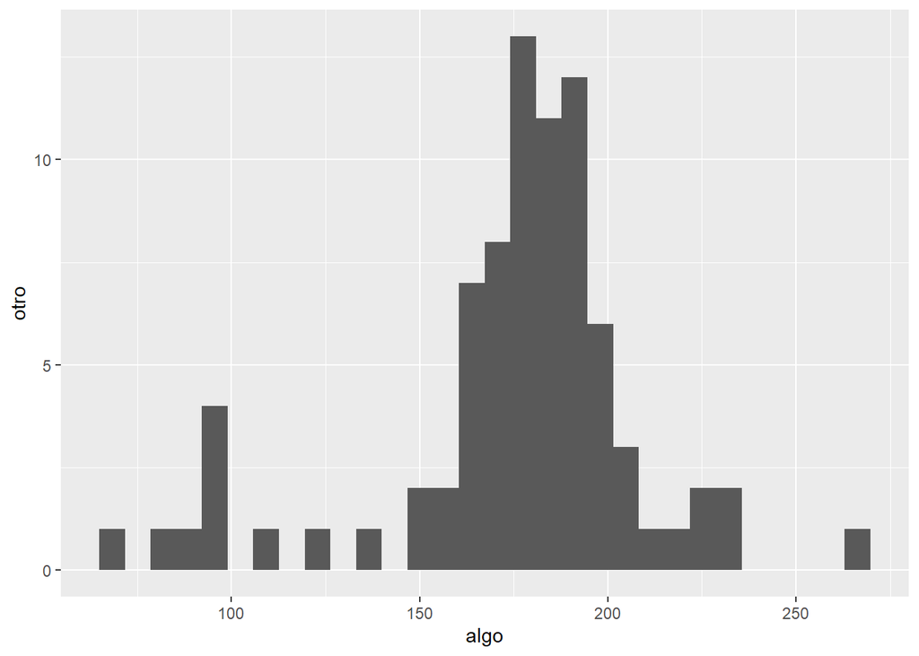

```r
library(ggplot2)
starwars %>%
  mutate(height_cat = ifelse(height > 100, "tall", "small")) %>%
  ggplot(aes(x=height, file=height_cat)) +
  geom_histogram()+
  labs(x='algo', y='otro')
```

#`dplyr`:`summarise()`,`mean()` - `summarise()` collapses a data frame to a single row( or one row per group if grouped)> - Useful for computing summary statistics: - `na.rm=TURE` ignores missing values in calculations

```r
starwars %>%
  summarise(height_cm = mean(height, na.rm=TRUE))
```

```
## # A tibble: 1 × 1
##   height_cm
##       <dbl>
## 1      175.
```

#`dplyr`:`summarise()`,`mean()`,`min()`,`max()`

```r
starwars %>%
  summarise(mean=mean(height, na.rm=T),
            min=min(height, na.rm=T),
            max=max(height, na.rm=T))
```

```
## # A tibble: 1 × 3
##    mean   min   max
##   <dbl> <int> <int>
## 1  175.    66   264
```

#`dplyr`: `group_by()`, `summarise()` - `group_by()` defines groups for group-wise operations - `summarise()` then computes summary satistics for each group

```r
starwars %>%
  group_by(species) %>%
  summarise(mean_height = mean(height, na.rm=T),
            sd_height= sd(height, na.rm=T)
            )
```

```
## # A tibble: 38 × 3
##    species   mean_height sd_height
##    <chr>           <dbl>     <dbl>
##  1 Aleena            79       NA
##  2 Besalisk         198       NA
##  3 Cerean           198       NA
##  4 Chagrian         196       NA
##  5 Clawdite         168       NA
##  6 Droid            131.      49.1
##  7 Dug              112       NA
##  8 Ewok              88       NA
##  9 Geonosian        183       NA
## 10 Gungan           209.      14.2
## # ℹ 28 more rows
```

```r
starwars %>%
  group_by(homeworld, gender) %>%
  summarise(mean_height_by_gender = mean(height, na.rm=T),
            sd_height_by_gender= sd(height, na.rm=T))
```

```
## # A tibble: 57 × 4
## # Groups:   homeworld [49]
##    homeworld      gender    mean_height_by_gender sd_height_by_gender
##    <chr>          <chr>                     <dbl>               <dbl>
##  1 Alderaan       feminine                   150                NA
##  2 Alderaan       masculine                  190.                2.12
##  3 Aleen Minor    masculine                   79                NA
##  4 Bespin         masculine                  175                NA
##  5 Bestine IV     <NA>                       180                NA
##  6 Cato Neimoidia masculine                  191                NA
##  7 Cerea          masculine                  198                NA
##  8 Champala       masculine                  196                NA
##  9 Chandrila      feminine                   150                NA
## 10 Concord Dawn   masculine                  183                NA
## # ℹ 47 more rows
```

# `dplyr`: `count()`

- takes the name of one or more columns that contain the groups we are interested in, and we can optionally sort in order

```r
starwars %>%
  group_by(species) %>%
  count(homeworld, sort = TRUE)
```

```
## # A tibble: 57 × 3
## # Groups:   species [38]
##    species  homeworld     n
##    <chr>    <chr>     <int>
##  1 Human    Tatooine      8
##  2 Human    <NA>          6
##  3 Human    Naboo         5
##  4 Droid    <NA>          3
##  5 Gungan   Naboo         3
##  6 Human    Alderaan      3
##  7 Droid    Tatooine      2
##  8 Human    Corellia      2
##  9 Human    Coruscant     2
## 10 Kaminoan Kamino        2
## # ℹ 47 more rows
```

#`dplyr`: `sample_n()` - randomly selects a specified number of rows from a data frame - Useful for exploring a subset of a large dataset

```r
starwars %>%
  sample_n(10)
```

```
## # A tibble: 10 × 14
##    name     height  mass hair_color skin_color eye_color birth_year sex   gender
##    <chr>     <int> <dbl> <chr>      <chr>      <chr>          <dbl> <chr> <chr>
##  1 Bail Pr…    191  NA   black      tan        brown             67 male  mascu…
##  2 Rugor N…    206  NA   none       green      orange            NA male  mascu…
##  3 Dooku       193  80   white      fair       brown            102 male  mascu…
##  4 Plo Koon    188  80   none       orange     black             22 male  mascu…
##  5 Luminar…    170  56.2 black      yellow     blue              58 fema… femin…
##  6 Yarael …    264  NA   none       white      yellow            NA male  mascu…
##  7 Ki-Adi-…    198  82   white      pale       yellow            92 male  mascu…
##  8 Mon Mot…    150  NA   auburn     fair       blue              48 fema… femin…
##  9 Han Solo    180  80   brown      fair       brown             29 male  mascu…
## 10 Ratts T…     79  15   none       grey, blue unknown           NA male  mascu…
## # ℹ 5 more variables: homeworld <chr>, species <chr>, films <list>,
## #   vehicles <list>, starships <list>
```

```r
starwars %>%
  sample_n(10,
           replace=T
           )
```

```
## # A tibble: 10 × 14
##    name     height  mass hair_color skin_color eye_color birth_year sex   gender
##    <chr>     <int> <dbl> <chr>      <chr>      <chr>          <dbl> <chr> <chr>
##  1 Dud Bolt     94    45 none       blue, grey yellow            NA male  mascu…
##  2 Gasgano     122    NA none       white, bl… black             NA male  mascu…
##  3 IG-88       200   140 none       metal      red               15 none  mascu…
##  4 Quarsh …    183    NA black      dark       brown             62 male  mascu…
##  5 Jabba D…    175  1358 <NA>       green-tan… orange           600 herm… mascu…
##  6 C-3PO       167    75 <NA>       gold       yellow           112 none  mascu…
##  7 Wilhuff…    180    NA auburn, g… fair       blue              64 male  mascu…
##  8 Beru Wh…    165    75 brown      light      blue              47 fema… femin…
##  9 Barriss…    166    50 black      yellow     blue              40 fema… femin…
## 10 Wedge A…    170    77 brown      fair       hazel             21 male  mascu…
## # ℹ 5 more variables: homeworld <chr>, species <chr>, films <list>,
## #   vehicles <list>, starships <list>
```

#`dplyr` recap - All verbs in `dplyr` share a consisten grammar: - The first argument is always a data.frame (or tibble) - The next arguments describe what to do with the columns - You can refer to columns directly (no `$` needed) - The result is always a new data frame (tibble)